# 单细胞多组学之CITEseq和RNAseq分析

huangzhihao@genomics.cn

2019年5月9日

## RNAseq数据聚类

本次多组学整合分析采用CITE-seq和RNA-seq数据，均来自2017年发表在Nature上的文章《Large-scale simultaneous measurement of epitopes and transcriptomes in single cells》，人脐带血单细胞，数据下载自GEO: GSE100866。CITE-seq检测了细胞表面13个蛋白的丰度。

```r
library(Seurat)
```

```r
library(ggplot2)
#setwd(dirname(rstudioapi::getActiveDocumentContext()$path))
```

加载数据，1273个细胞的RNA表达矩阵cbmc和13个蛋白的标签丰度cbmc.adt。

```r
cbmc.rna <- read.table("mat_selectcell.txt.gz",header=T,row.names=1)
cbmc.adt <- read.csv("adt_selectcell.csv",header=T,row.names=1)
cbmc.rna[1:5,1:5]
```

```
##          CAGCATAAGAGTACAT TGGTTAGAGATGTTAG TACGGGCTCATTATCC
## A1BG                    0                0                0
## A1BG-AS1                0                0                0
## A1CF                    0                0                0
## A2M                     0                0                0
## A2M-AS1                 1                0                0
##          TAGCCGGGTCTCACCT GAAGCAGAGGTGCTAG
## A1BG                    0                0
## A1BG-AS1                0                0
## A1CF                    0                0
## A2M                     0                0
## A2M-AS1                 0                1
```

```r
cbmc.adt[1:5,1:5]
```

```
##        CAGCATAAGAGTACAT TGGTTAGAGATGTTAG TACGGGCTCATTATCC TAGCCGGGTCTCACCT
## CD3                1085             3232             1754             1509
## CD4                  23             2720             1030             1440
## CD8                8689             3581              276               26
## CD45RA             5915            11822             5722             7853
## CD56                 31              100               48               30
##        GAAGCAGAGGTGCTAG
## CD3                3208
## CD4                1579
## CD8                8194
## CD45RA            17498
## CD56                 32
```

去除3个丰度不高的蛋白。

```r
# we observed poor enrichments for CCR5, CCR7, and CD10 - and therefore remove them from the matrix
# (optional)
cbmc.adt <- cbmc.adt[setdiff(rownames(x = cbmc.adt), c("CCR5", "CCR7", "CD10")), ]
```

先对RNA数据进行聚类分析，PCA降维，聚类。

```r
cbmc <- CreateSeuratObject(counts = cbmc.rna)
# standard log-normalization
cbmc <- NormalizeData(cbmc)
# choose ~1k variable features
cbmc <- FindVariableFeatures(cbmc)
# standard scaling (no regression)
cbmc <- ScaleData(cbmc)
```

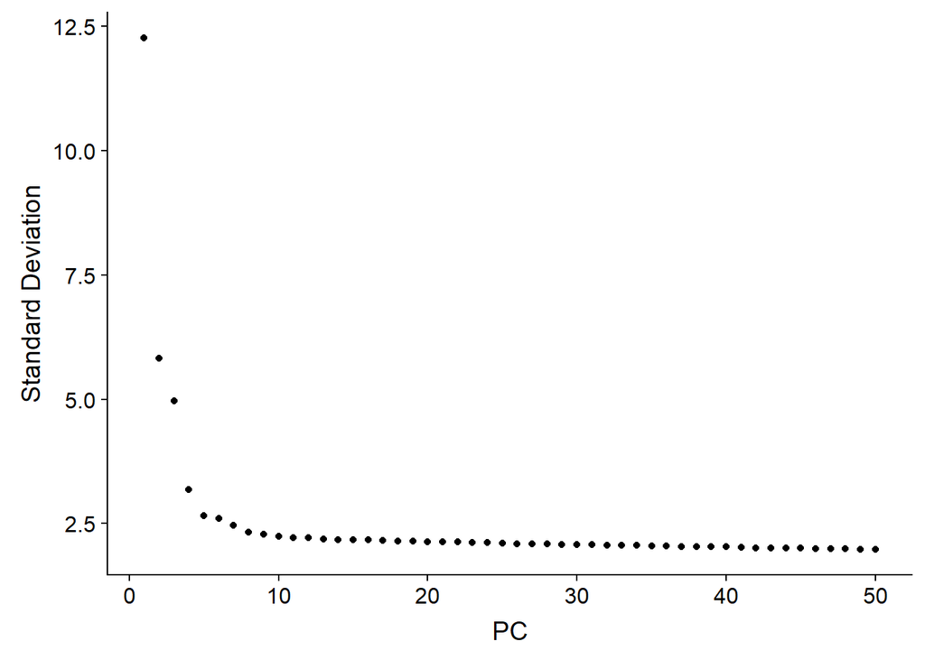

```r
# Run PCA, select 20 PCs for tSNE visualization and graph-based clustering
cbmc <- RunPCA(cbmc, verbose = FALSE)
ElbowPlot(cbmc, ndims = 50)
```

```r
cbmc <- FindNeighbors(cbmc, dims = 1:20)
cbmc <- FindClusters(cbmc, resolution = 0.4)
```

```
## Modularity Optimizer version 1.3.0 by Ludo Waltman and Nees Jan van Eck
##
## Number of nodes: 1273
## Number of edges: 62707
##
## Running Louvain algorithm...
## Maximum modularity in 10 random starts: 0.8758
## Number of communities: 5
## Elapsed time: 0 seconds
```

```r
cbmc <- RunTSNE(cbmc, dims = 1:20)
```

鉴定每个分群的差异表达基因（DEG），根据DEG和已知marker基因鉴定细胞类型。

```
##               p_val avg_logFC pct.1 pct.2    p_val_adj cluster  gene
## ITM2A 1.251359e-100 1.2448995 0.862 0.355 2.565411e-96       0 ITM2A
## LDHB   6.468177e-90 0.8197542 0.983 0.755 1.326041e-85       0  LDHB
## IL7R   3.230231e-87 0.9978627 0.924 0.406 6.622297e-83       0  IL7R
## RPL31  2.349453e-78 0.5297153 1.000 0.995 4.816615e-74       0 RPL31
## RPL30  1.108106e-77 0.4490668 1.000 1.000 2.271727e-73       0 RPL30
## TRBC2  3.878869e-76 0.8762363 0.928 0.505 7.952069e-72       0 TRBC2
```

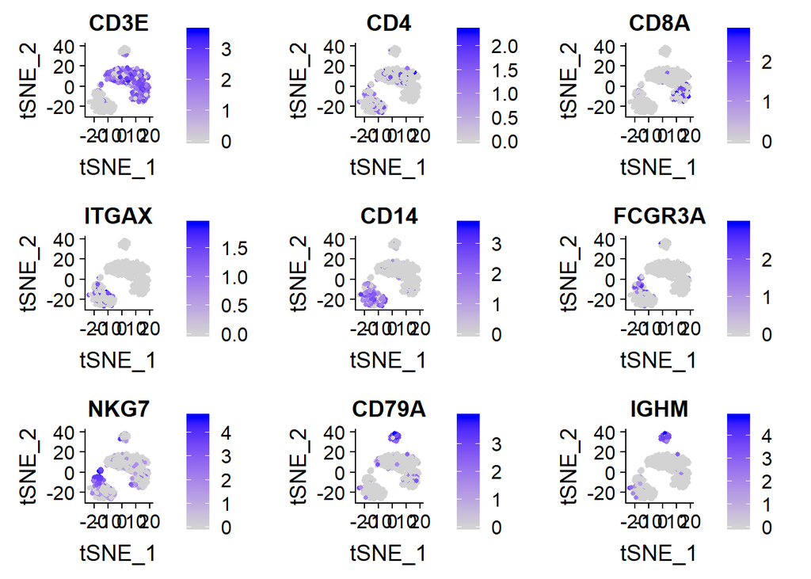

定义分群，用tSNE展示分群结果。

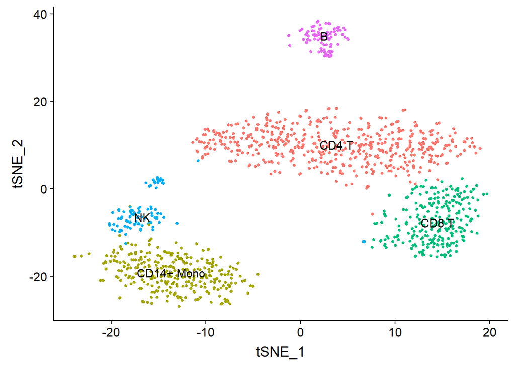

```r
new.cluster.ids <- c("CD4 T", "CD14+ Mono","CD8 T", "NK", "B")
names(new.cluster.ids) <- levels(cbmc)
cbmc <- RenameIdents(cbmc, new.cluster.ids)
DimPlot(cbmc, label = TRUE) + NoLegend()
```

## CITEseq数据与RNAseq数据整合比较

在RNAseq的seurat对象中加入CITEseq数据。

```r
# If you are interested in how these data are internally stored, you can check out the Assay
# class, which is defined in objects.R; note that all single-cell expression data, including RNA
# data, are still stored in Assay objects, and can also be accessed using GetAssayData
cbmc[["ADT"]] <- CreateAssayObject(counts = cbmc.adt)
# Now we can repeat the preprocessing (normalization and scaling) steps that we typically run
# with RNA, but modifying the 'assay' argument.  For CITE-seq data, we do not recommend typical
# LogNormalization. Instead, we use a centered log-ratio (CLR) normalization, computed
# independently for each feature.  This is a slightly improved procedure from the original
# publication.
cbmc <- NormalizeData(cbmc, assay = "ADT", normalization.method = "CLR")
```

```
## Normalizing across features
```

```r
cbmc <- ScaleData(cbmc, assay = "ADT")
```

RNA基因表达量和CITEseq蛋白标签表达量同一张图展示。

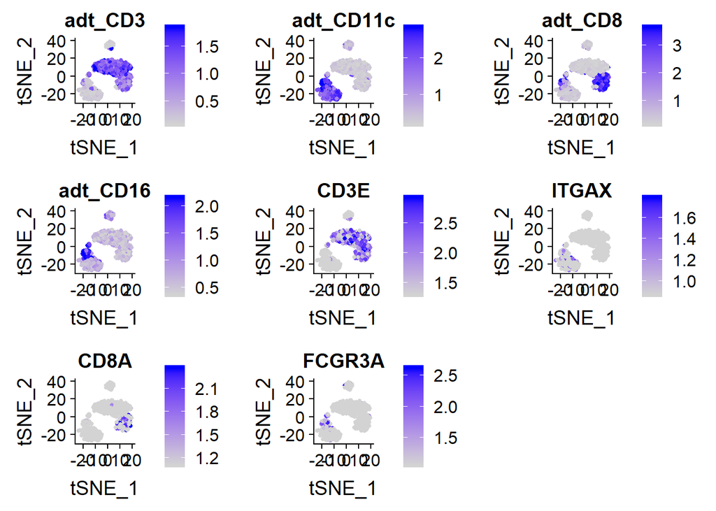

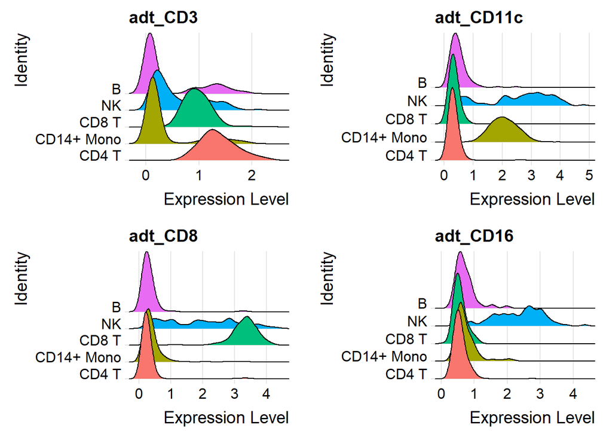

CITEseq蛋白丰度展示，类似FACS图。

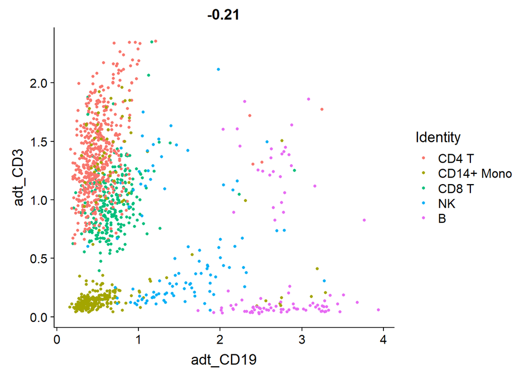

```r
# Draw ADT scatter plots (like biaxial plots for FACS).
FeatureScatter(cbmc, feature1 = "adt_CD19", feature2 = "adt_CD3")
```

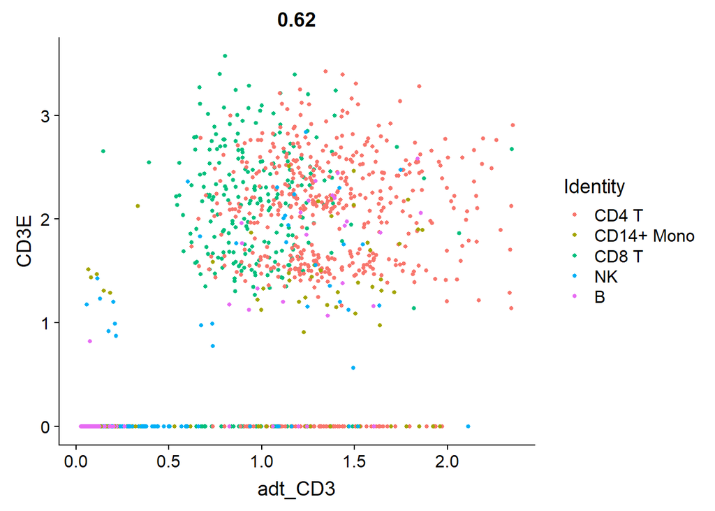

```r
# view relationship between protein and RNA
FeatureScatter(cbmc, feature1 = "adt_CD3", feature2 = "CD3E")
```

比较CD4+ T细胞和CD8+ T细胞。

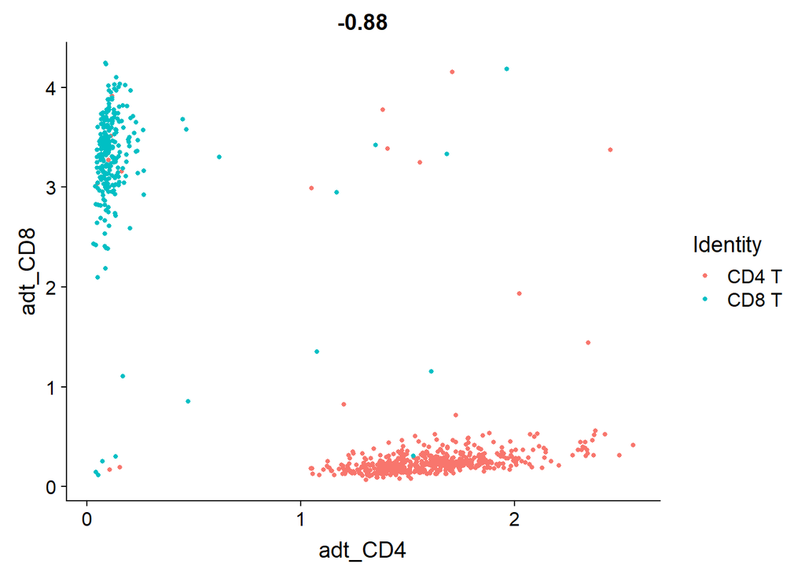

```r
# Let's plot CD4 vs CD8 levels in T cells
tcells <- subset(cbmc, idents = c("CD4 T", 'CD8 T'))
FeatureScatter(tcells, feature1 = "adt_CD4", feature2 = "adt_CD8")
```

与RNA不同，CD4和CD8蛋白具有很高的丰度，所以基本所有细胞都有表达相应的marker，不存在drop-out。

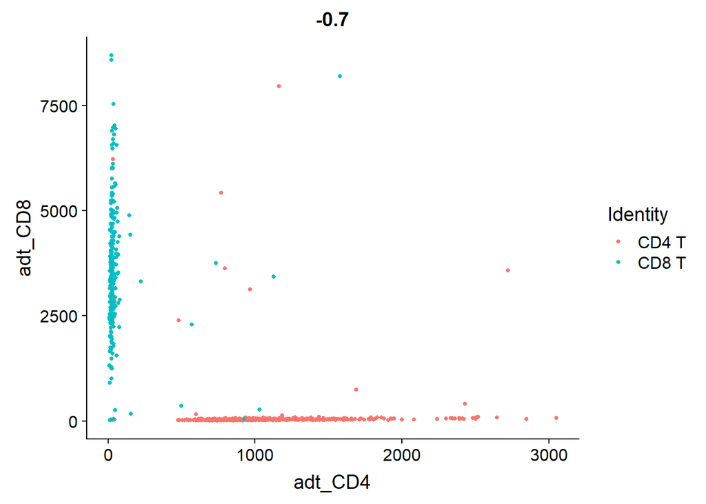

```r
# # Let's look at the raw (non-normalized) ADT counts. You can see the values are quite high,
# particularly in comparison to RNA values. This is due to the significantly higher protein copy
# number in cells, which significantly reduces 'drop-out' in ADT data
FeatureScatter(tcells, feature1 = "adt_CD4", feature2 = "adt_CD8", slot = "counts")
```

热图展示ADT在不同分群的丰度。

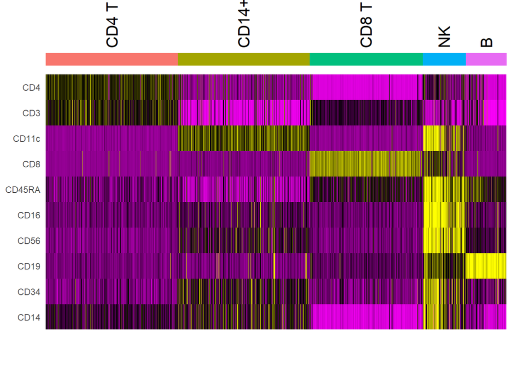

```r
# Downsample the clusters to a maximum of 300 cells each (makes the heatmap easier to see for
# small clusters)
cbmc.small <- subset(cbmc, downsample = 300)
#cbmc.small <- cbmc
# Find protein markers for all clusters, and draw a heatmap
adt.markers <- FindAllMarkers(cbmc.small, assay = "ADT", only.pos = TRUE)
DoHeatmap(cbmc.small, features = unique(adt.markers$gene), assay = "ADT", angle = 90) + NoLegend()
```

选择ADT为默认的对象，后面针对ADT分析

```r
# Because we're going to be working with the ADT data extensively, we're going to switch the
# default assay to the 'CITE' assay.  This will cause all functions to use ADT data by default,
# rather than requiring us to specify it each time
DefaultAssay(cbmc) <- "ADT"
cbmc <- RunPCA(cbmc, features = rownames(cbmc), reduction.name = "pca_adt", reduction.key = "pca_adt_",
               verbose = FALSE)
```

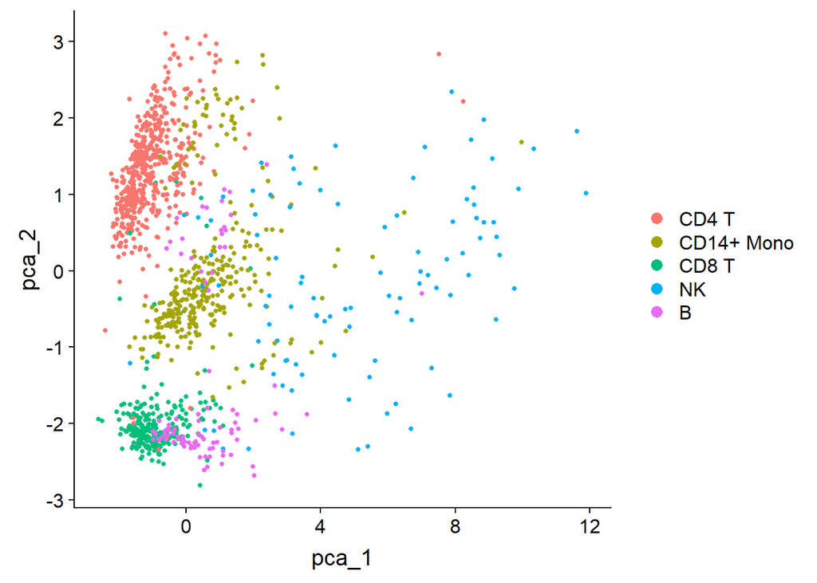

```r
DimPlot(cbmc, reduction = "pca_adt")
```

因为ADT只有10个蛋白，不用PCA降维选取特征，直接计算欧式距离，然后聚类。

```r
# Since we only have 10 markers, instead of doing PCA, we'll just use a standard euclidean
# distance matrix here.  Also, this provides a good opportunity to demonstrate how to do
# visualization and clustering using a custom distance matrix in Seurat
adt.data <- GetAssayData(cbmc, slot = "data")
adt.dist <- dist(t(adt.data))
# Before we recluster the data on ADT levels, we'll stash the RNA cluster IDs for later
cbmc[["rnaClusterID"]] <- Idents(cbmc)
# Now, we rerun tSNE using our distance matrix defined only on ADT (protein) levels.
cbmc[["tsne_adt"]] <- RunTSNE(adt.dist, assay = "ADT", reduction.key = "adtTSNE_")
cbmc[["adt_snn"]] <- FindNeighbors(adt.dist)$snn
```

```
## Building SNN based on a provided distance matrix
```

```r
cbmc <- FindClusters(cbmc, resolution = 0.2, graph.name = "adt_snn")
```

```
## Modularity Optimizer version 1.3.0 by Ludo Waltman and Nees Jan van Eck
##
## Number of nodes: 1273
## Number of edges: 38931
##
## Running Louvain algorithm...
## Maximum modularity in 10 random starts: 0.9478
## Number of communities: 7
## Elapsed time: 0 seconds
```

根据RNA聚类结果的细胞类型鉴定ADT的分群。

```r
# We can compare the RNA and protein clustering, and use this to annotate the protein clustering
# (we could also of course use FindMarkers)
clustering.table <- table(Idents(cbmc), cbmc$rnaClusterID)
clustering.table
```

```
##
##     CD4 T CD14+ Mono CD8 T  NK   B
##   0   497          0     8  17   0
##   1    12          6   248   4   1
##   2     0        240     1   2   0
##   3     2         10     0  74   1
##   4     0          8     0   1  68
##   5     2         45     0   0   0
##   6     2          1     0   0  23
```

```r
new.cluster.ids <- c("CD4 T","CD8 T", "CD14+ Mono", "NK", "B","CD14+ Mono","B")
names(new.cluster.ids) <- levels(cbmc)
cbmc <- RenameIdents(cbmc, new.cluster.ids)
```

比较RNAseq和CITEseq的细胞类型鉴定结果。

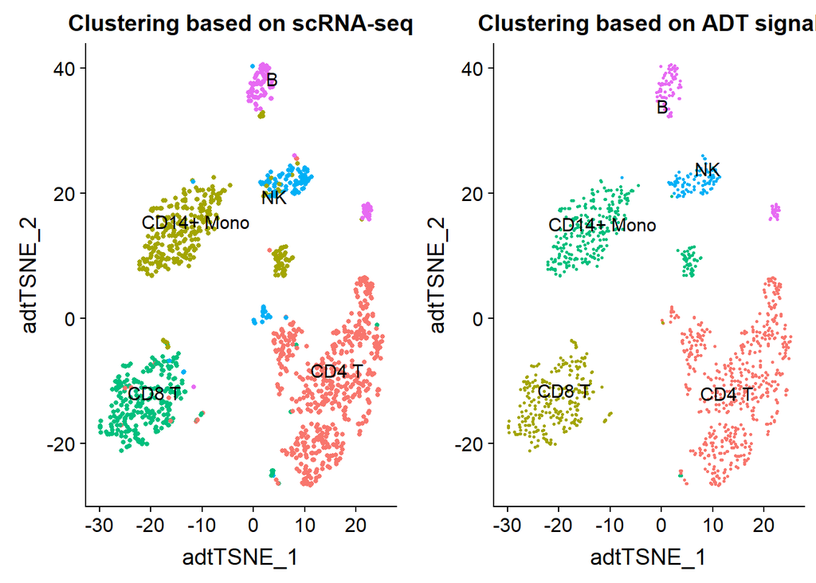

```r
tsne_rnaClusters <- DimPlot(cbmc, reduction = "tsne_adt", group.by = "rnaClusterID") + NoLegend()
tsne_rnaClusters <- tsne_rnaClusters + ggtitle("Clustering based on scRNA-seq") + theme(plot.title = element_text(hjust = 0.5))
tsne_rnaClusters <- LabelClusters(plot = tsne_rnaClusters, id = "rnaClusterID", size = 4)

tsne_adtClusters <- DimPlot(cbmc, reduction = "tsne_adt", pt.size = 0.5) + NoLegend()
tsne_adtClusters <- tsne_adtClusters + ggtitle("Clustering based on ADT signal") + theme(plot.title = element_text(hjust = 0.5))
tsne_adtClusters <- LabelClusters(plot = tsne_adtClusters, id = "ident", size = 4)

# Note: for this comparison, both the RNA and protein clustering are visualized on a tSNE
# generated using the ADT distance matrix.
CombinePlots(plots = list(tsne_rnaClusters, tsne_adtClusters), ncol = 2)
```

CD4+ T细胞和CD8+ T细胞的比较。

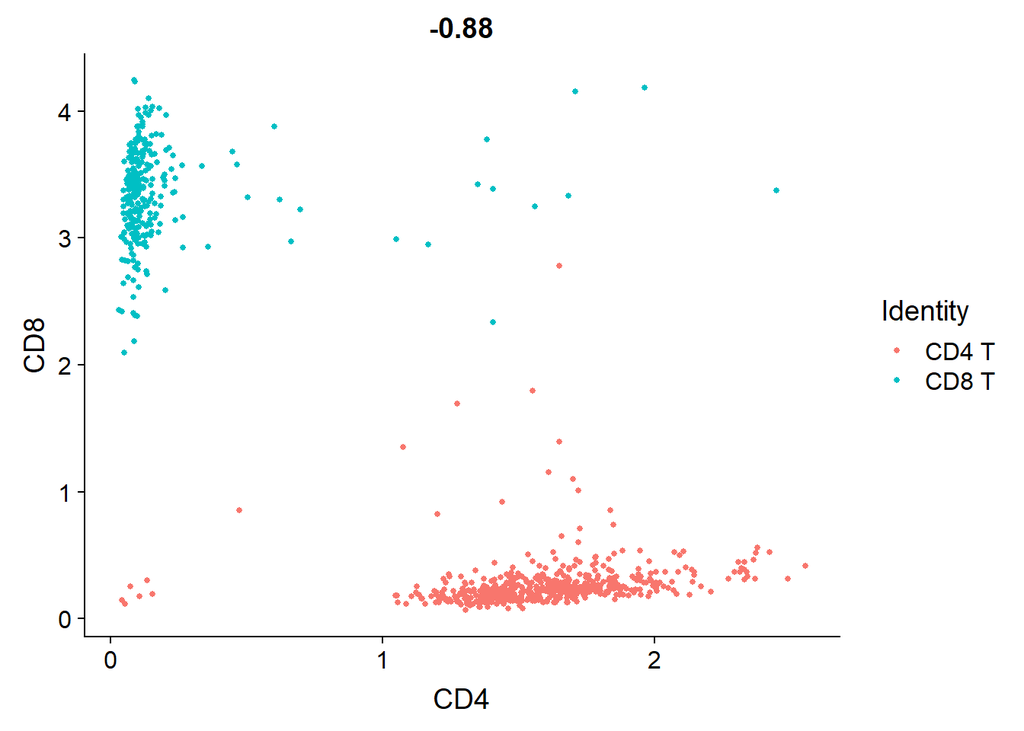

```r
tcells <- subset(cbmc, idents = c("CD4 T", "CD8 T"))
FeatureScatter(tcells, feature1 = "CD4", feature2 = "CD8")
```

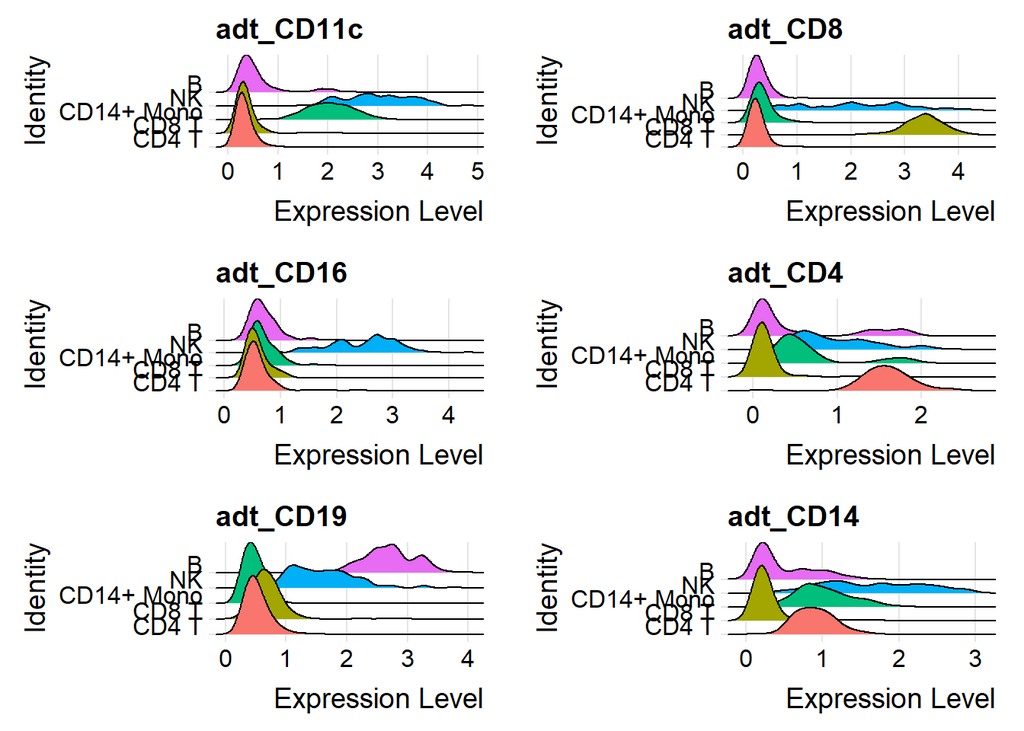

```r
RidgePlot(cbmc, features = c("adt_CD11c", "adt_CD8", "adt_CD16", "adt_CD4", "adt_CD19", "adt_CD14"),
          ncol = 2)
```

保存数据对象，以便以后快速加载。

```r
saveRDS(cbmc, file = "./cbmc_multimodal.rds")
```